# Lecture 3

August 2021

## What to do with data?

- You have your clean data, now what?
- You need to understand how variables **move together**!
- Two main tools:
  - Correlation analysis.
  - Regression analysis.

[figure not shown]

## Motivation

- In this lecture, we are going to have a look at S&P stock returns.
- We select the 10 biggest capitalization.
  - Apple (AAPL)
  - Microsoft (MSFT)
  - Amazon (AMZN)
  - Facebook (FB)
  - Alphabet Inc. A shares (GOOGL)
  - Alphabet Inc. C shares (GOOG)
  - Berkshire Hathaway (BRK-B)
  - JP Morgan (JPM)
  - Tesla (TSLA)
  - Johnson & Johnson (JNJ)

## Portfolio optimization with stocks

- You may know that two principles are sacred in portfolio optimization:
  - Diversification.
  - the more asset returns co-move, the less you want both of them.
- More formally, Markowitz portfolio (see investment class) tells you that the optimal asset allocation depends on the **inverse covariance matrix** of asset returns.
- We will explore this idea with our 10 stocks.

## Constructing stock returns

## Stock returns analysis

```python
import yfinance as yf

assets = ['AAPL', 'MSFT', 'AMZN', 'FB', 'GOOGL',
          'GOOG', 'BRK-B', 'JPM', 'TSLA', 'JNJ']
prices =  yf.download(assets,
                      start='2000-01-01',
                      end='2020-12-31',
                      progress=False)

prices.shape
```

```
## (5283, 60)
```

```python
prices.columns.droplevel(1).drop_duplicates()
```

```
## Index(['Adj Close', 'Close', 'High', 'Low', 'Open', 'Volume'], dtype='object')
```

## Stock returns analysis

- We need to create the returns data.
- Let’s drop every variable but the close first.

```python
variable_names = prices.columns.droplevel(1).drop_duplicates().to_list()
variable_names.remove('Close')
print(variable_names)
```

```
## ['Adj Close', 'High', 'Low', 'Open', 'Volume']
```

```python
for asset_name in assets:
  for variable in variable_names:
    column_name = (variable, asset_name)
    del prices[column_name]
```

## Stock returns analysis

```python
print(prices)
```

```
##                  Close               ...
##                   AAPL         AMZN  ...        MSFT        TSLA
## Date                                 ...
## 2000-01-03    0.999442    89.375000  ...   58.281250         NaN
## 2000-01-04    0.915179    81.937500  ...   56.312500         NaN
## 2000-01-05    0.928571    69.750000  ...   56.906250         NaN
## 2000-01-06    0.848214    65.562500  ...   55.000000         NaN
## 2000-01-07    0.888393    69.562500  ...   55.718750         NaN
## ...                ...          ...  ...         ...         ...
## 2020-12-23  130.960007  3185.270020  ...  221.020004  645.979980
## 2020-12-24  131.970001  3172.689941  ...  222.750000  661.770020
## 2020-12-28  136.690002  3283.959961  ...  224.960007  663.690002
## 2020-12-29  134.869995  3322.000000  ...  224.149994  665.989990
## 2020-12-30  133.720001  3285.850098  ...  221.679993  694.780029
##
## [5283 rows x 10 columns]
```

## Some plot

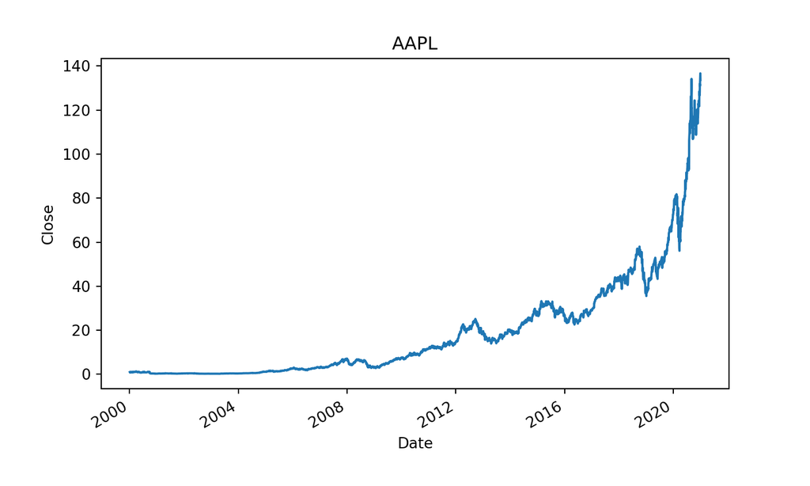

```python
import matplotlib.pyplot as plt
prices[('Close', 'AAPL')].plot();
plt.xlabel("Date"); plt.ylabel("Close"); plt.title("AAPL");
plt.show()
```

## Some plots

- With a multiple layout and `matplotlib`

```python
fig = plt.figure();
fig, axs = plt.subplots(5, 2);
count = 0
for i in range(0,5):
  for j in range(0,2):
    axs[i,j].plot(prices['Close'][assets[count]]);
    axs[i,j].set_title(assets[count]);
    count = count + 1
plt.tight_layout();
```

## Some plots

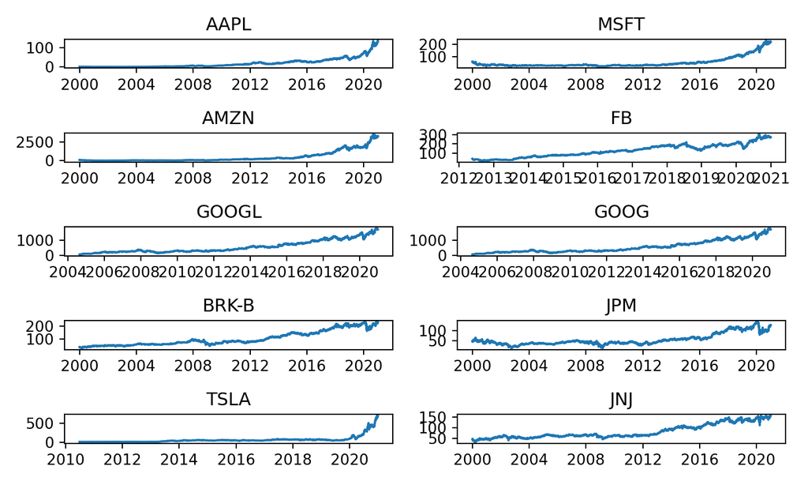

## Creating returns

- Now we need to transform these prices into returns.
- Fortunately, there is a function already done for us!
- We use `.pct_change`

```python
returns = prices.pct_change()
returns = returns.droplevel(0, axis = 1)
returns
```

```
##                 AAPL      AMZN     BRK-B  ...       JPM      MSFT      TSLA
## Date                                      ...
## 2000-01-03       NaN       NaN       NaN  ...       NaN       NaN       NaN
## 2000-01-04 -0.084310 -0.083217 -0.034561  ... -0.027444 -0.033780       NaN
## 2000-01-05  0.014633 -0.148741  0.016432  ... -0.006173  0.010544       NaN
## 2000-01-06 -0.086538 -0.060036  0.041571  ...  0.014197 -0.033498       NaN
## 2000-01-07  0.047369  0.061010  0.008869  ...  0.018373  0.013068       NaN
## ...              ...       ...       ...  ...       ...       ...       ...
## 2020-12-23 -0.006976 -0.006627  0.010636  ...  0.027944 -0.013039  0.008808
## 2020-12-24  0.007712 -0.003949  0.010212  ... -0.004398  0.007827  0.024444
## 2020-12-28  0.035766  0.035071  0.008299  ...  0.006585  0.009921  0.002901
## 2020-12-29 -0.013315  0.011584  0.005079  ... -0.002633 -0.003601  0.003465
## 2020-12-30 -0.008527 -0.010882  0.000348  ...  0.002800 -0.011019  0.043229
##
## [5283 rows x 10 columns]
```

## Plotting returns

```python
import plotnine as plt9

returns_plot = returns.stack().reset_index()
returns_plot.columns = ["Date", "stock", "return"]
(
  plt9.ggplot(returns_plot)
    + plt9.aes(x = "Date", y = "return", colour = "stock")
    + plt9.facet_wrap('stock')
    + plt9.geom_line()
    + plt9.theme(axis_text_x=plt9.element_text(angle=45),
                 strip_text_y=plt9.element_text(size=5),
                 subplots_adjust={'right': 0.8})
    + plt9.labs(title = "Stock returns", y = "Natural daily units", x = "")
)
```

## Plotting returns

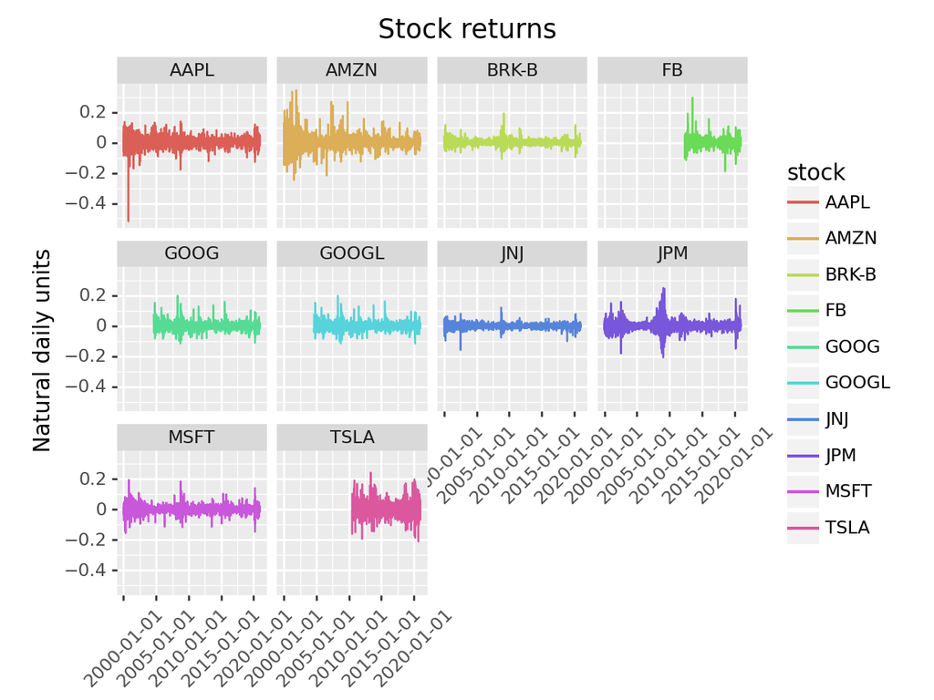

## Covariance Analysis

## Statistical moments to analyze co-movement

- Covariance and correlations are the main objects of interest to measure how variables move together.
- The covariance between \(X\) and \(Y\) is given by: \[ Cov(X,Y) = E(XY) - E(X)E(Y)\,. \]
- for vectors, the covariance is a matrix where entry \((i,j)\) is the covariance of \(X_i\) and \(X_j\).
- In practice, computation is performed with: \[ \widehat{Cov}(X,Y) = \frac{1}{T}\sum_{t=1}^T \left(x_{t} - \overline{x}\right)\left(y_{t}-\overline{y}\right)\,. \]
- Standard deviation is given by: \[ \widehat{\sigma}_X = \sqrt{\frac{1}{T-1}\sum_{t=1}^T \left(x_{t} - \overline{x}\right)^2} \]

## Moments to analyze co-movement

- Combining both, we can obtain **Pearson Correlation**: \[ \widehat{\rho}_{X,Y} = \frac{\widehat{Cov}(X,Y) }{\widehat{\sigma}_X \cdot \widehat{\sigma}_Y} \]
- \(\widehat{\rho}_{X,Y} \in [-1,1]\).
- If \(\widehat{\rho}_{X,Y} =0\), the variables are **uncorrelated** (they don’t co-move).
- If \(\widehat{\rho}_{X,Y} =\pm 1\), the variables are perfectly correlated, hence redundant.
- Other less popular correlation measures exist, **Spearman’s** and **Kendall’s** rank correlations.

## Calling correlations in Python

- You can compute covariance and correlations between columns directly with `pandas`.

```python
import numpy as np
round(100*np.sqrt(returns.cov()),2)
```

```
##        AAPL  AMZN  BRK-B    FB  GOOG  GOOGL   JNJ   JPM  MSFT  TSLA
## AAPL   2.56  1.72   0.95  1.30  1.43   1.42  0.85  1.52  1.52  1.38
## AMZN   1.72  3.25   1.04  1.43  1.51   1.51  0.80  1.61  1.63  1.49
## BRK-B  0.95  1.04   1.44  0.98  1.04   1.04  0.78  1.33  0.99  1.09
## FB     1.30  1.43   0.98  2.36  1.37   1.37  0.82  1.09  1.27  1.46
## GOOG   1.43  1.51   1.04  1.37  1.93   1.92  0.89  1.41  1.32  1.33
## GOOGL  1.42  1.51   1.04  1.37  1.92   1.92  0.89  1.41  1.32  1.33
## JNJ    0.85  0.80   0.78  0.82  0.89   0.89  1.24  1.01  0.92  0.83
## JPM    1.52  1.61   1.33  1.09  1.41   1.41  1.01  2.48  1.49  1.28
## MSFT   1.52  1.63   0.99  1.27  1.32   1.32  0.92  1.49  1.95  1.35
## TSLA   1.38  1.49   1.09  1.46  1.33   1.33  0.83  1.28  1.35  3.55
```

## Calling correlations in Python

- You can compute covariance and correlations between columns directly with `pandas`.

```python
returns.corr().round(2)
```

```
##        AAPL  AMZN  BRK-B    FB  GOOG  GOOGL   JNJ   JPM  MSFT  TSLA
## AAPL   1.00  0.35   0.24  0.39  0.50   0.50  0.23  0.36  0.46  0.30
## AMZN   0.35  1.00   0.23  0.45  0.49   0.49  0.16  0.32  0.42  0.31
## BRK-B  0.24  0.23   1.00  0.34  0.41   0.41  0.34  0.49  0.35  0.27
## FB     0.39  0.45   0.34  1.00  0.50   0.50  0.26  0.30  0.42  0.26
## GOOG   0.50  0.49   0.41  0.50  1.00   1.00  0.37  0.43  0.53  0.30
## GOOGL  0.50  0.49   0.41  0.50  1.00   1.00  0.38  0.43  0.53  0.30
## JNJ    0.23  0.16   0.34  0.26  0.37   0.38  1.00  0.33  0.35  0.18
## JPM    0.36  0.32   0.49  0.30  0.43   0.43  0.33  1.00  0.46  0.25
## MSFT   0.46  0.42   0.35  0.42  0.53   0.53  0.35  0.46  1.00  0.32
## TSLA   0.30  0.31   0.27  0.26  0.30   0.30  0.18  0.25  0.32  1.00
```

- This is already very informative!

## Rank Correlations in Python

- You can also compute rank correlations

```python
returns.corr(method = 'spearman').round(2)
```

```
##        AAPL  AMZN  BRK-B    FB  GOOG  GOOGL   JNJ   JPM  MSFT  TSLA
## AAPL   1.00  0.41   0.26  0.41  0.48   0.48  0.23  0.37  0.48  0.31
## AMZN   0.41  1.00   0.28  0.53  0.55   0.55  0.23  0.35  0.46  0.35
## BRK-B  0.26  0.28   1.00  0.32  0.39   0.39  0.31  0.45  0.31  0.26
## FB     0.41  0.53   0.32  1.00  0.57   0.58  0.23  0.31  0.44  0.31
## GOOG   0.48  0.55   0.39  0.57  1.00   1.00  0.33  0.42  0.50  0.33
## GOOGL  0.48  0.55   0.39  0.58  1.00   1.00  0.33  0.42  0.50  0.33
## JNJ    0.23  0.23   0.31  0.23  0.33   0.33  1.00  0.33  0.33  0.18
## JPM    0.37  0.35   0.45  0.31  0.42   0.42  0.33  1.00  0.43  0.24
## MSFT   0.48  0.46   0.31  0.44  0.50   0.50  0.33  0.43  1.00  0.31
## TSLA   0.31  0.35   0.26  0.31  0.33   0.33  0.18  0.24  0.31  1.00
```

## Rank Correlations in Python

- You can also compute rank correlations

```python
returns.corr(method = 'kendall').round(2)
```

```
##        AAPL  AMZN  BRK-B    FB  GOOG  GOOGL   JNJ   JPM  MSFT  TSLA
## AAPL   1.00  0.29   0.18  0.29  0.35   0.35  0.16  0.26  0.34  0.21
## AMZN   0.29  1.00   0.20  0.39  0.40   0.40  0.16  0.25  0.33  0.24
## BRK-B  0.18  0.20   1.00  0.22  0.27   0.27  0.22  0.33  0.22  0.18
## FB     0.29  0.39   0.22  1.00  0.42   0.43  0.16  0.21  0.31  0.21
## GOOG   0.35  0.40   0.27  0.42  1.00   0.96  0.23  0.30  0.36  0.22
## GOOGL  0.35  0.40   0.27  0.43  0.96   1.00  0.23  0.29  0.36  0.22
## JNJ    0.16  0.16   0.22  0.16  0.23   0.23  1.00  0.23  0.23  0.12
## JPM    0.26  0.25   0.33  0.21  0.30   0.29  0.23  1.00  0.31  0.16
## MSFT   0.34  0.33   0.22  0.31  0.36   0.36  0.23  0.31  1.00  0.21
## TSLA   0.21  0.24   0.18  0.21  0.22   0.22  0.12  0.16  0.21  1.00
```

- Be careful! All these correlations are computed by throwing away the rows with `NA`.
- Even if `GOOGL` and `MSFT` are observable for longer periods than `FB`, computations are performed for data observed only when `FB` is observable.
- You need to perform a loop to obtain more flexible correlations.

## Exercise

```python
import scipy.linalg as la
# CORR_MAT is your correlation matrix
eigenvalues = la.eig(CORR_MAT)
```

## Regression analysis

## The linear regression framework

- The other tool to check the relationship between variables is the **regression**.

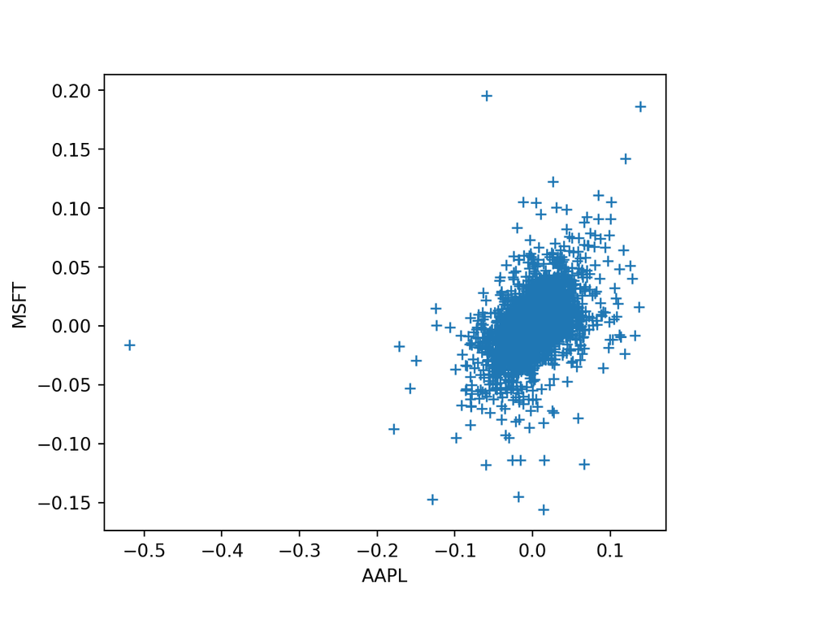

```python
plt.plot(returns['AAPL'], returns['MSFT'], '+'); plt.xlabel('AAPL'); plt.ylabel('MSFT');
plt.show();
```

## The linear regression framework

- The other tool to check the relationship between variables is the **regression**.

[figure not shown]

```python
plt.plot(returns['AAPL'], returns['MSFT'], '+'); plt.xlabel('AAPL'); plt.ylabel('MSFT');
plt.show();
```

## Performing regressions in Python

- Let us use the example of the CAPM.
- We will use a market portfolio \(R_t\) defined as the mean of our 10 returns.
- We assume the riskless rate is zero.
- The model writes: \[ r_{i,t} = \alpha_i + \beta_i \cdot R_t + \varepsilon_{i,t} \]
- We can estimate this regression with the `statsmodel.api` library.

```python
import statsmodels.api as sm
```

- Other libraries also provide linear (and other) regression(s).
  - `NumPy` provides the `polyfit` function for polynomial regressions.
  - The Scikit-Learn library `sklearn` has the `LinearRegression` function.

## Performing regressions in Python

- Let us run the regression for `AAPL`.

```python
# Computing the market return
Mkt = returns.mean(axis = 1)
Mkt.name = "Market"

# Adding the constant in the regression
regressors = sm.add_constant(Mkt)
regressors
```

```
##             const    Market
## Date
## 2000-01-03    1.0       NaN
## 2000-01-04    1.0 -0.049987
## 2000-01-05    1.0 -0.017125
## 2000-01-06    1.0 -0.015495
## 2000-01-07    1.0  0.031871
## ...           ...       ...
## 2020-12-23    1.0  0.002927
## 2020-12-24    1.0  0.004985
## 2020-12-28    1.0  0.018353
## 2020-12-29    1.0 -0.001293
## 2020-12-30    1.0 -0.001255
##
## [5283 rows x 2 columns]
```

## Performing regressions in Python

- Let us run the regression for `AAPL`.

```python
# Telling Python which model we are going to fit
Model = sm.OLS(returns['AAPL'], regressors, missing = 'drop')

# Fitting the model
Fit = Model.fit()
# print(Fit.summary())
```

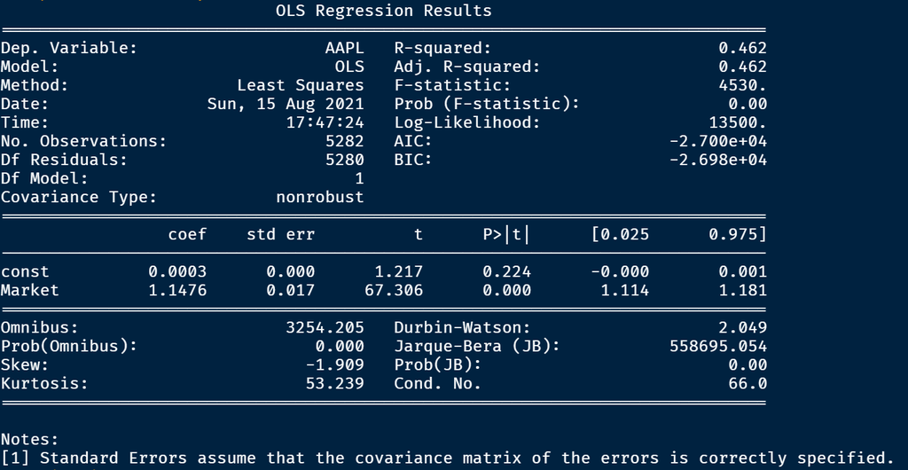

## Regression results

```python
from statsmodels.iolib.summary2 import summary_col
# print(summary_col([Fit],stars=True))
```

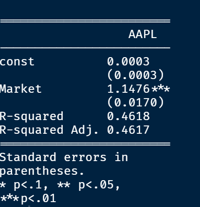

## Running regressions

## Exercise

1. Download the same 10 stocks data.
2. Perform the CAPM regression for all stocks using a `for` loop, and store the results in a list or a dictionnary.
3. What is the stock with the highest/lowest alpha?
4. What is the stock with the highest/lowest beta?
5. Looking aat the \(R^2\), what are the stock returns mostly correlated with the market?
6. Looking at the 10 betas, are the stock returns positively or negatively correlated?

## Presentations and reports with RMarkdown

## Performing presentations and code

- These slides have been performed with `RMarkdown`, a module of `RStudio`.

[figure not shown]

## Rstudio

- Presentation of `RStudio` is similar to `Spyder`, except it’s mainly done for `R`.
- You can also use `Python` with `Rstudio`.
- You just need to run the following piece of code:

```r
install.packages("reticulate") # Installs the module to perform Python
# The installation is to be done only ONCE!
library(reticulate) # Calls the package

# Install Python modules
py_install("numpy")
py_install("pandas")
py_install("matplotlib")

# Starting Python
repl_python()
```

- The console tells you `Python` starts:

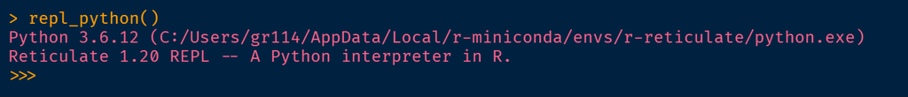

## The knitr package

- The `knitr` package allows you to create `Rmarkdown` documents.

```r
install.packages("knitr")
```

- Then you can start with a `Rmarkdown` document.
- You can create two types of documents:
  - Report
  - Slides
- Both of them can be either HTML (like these slides) or PDF.

## Creating Markdown docs

[figure not shown]

## Creating Markdown docs

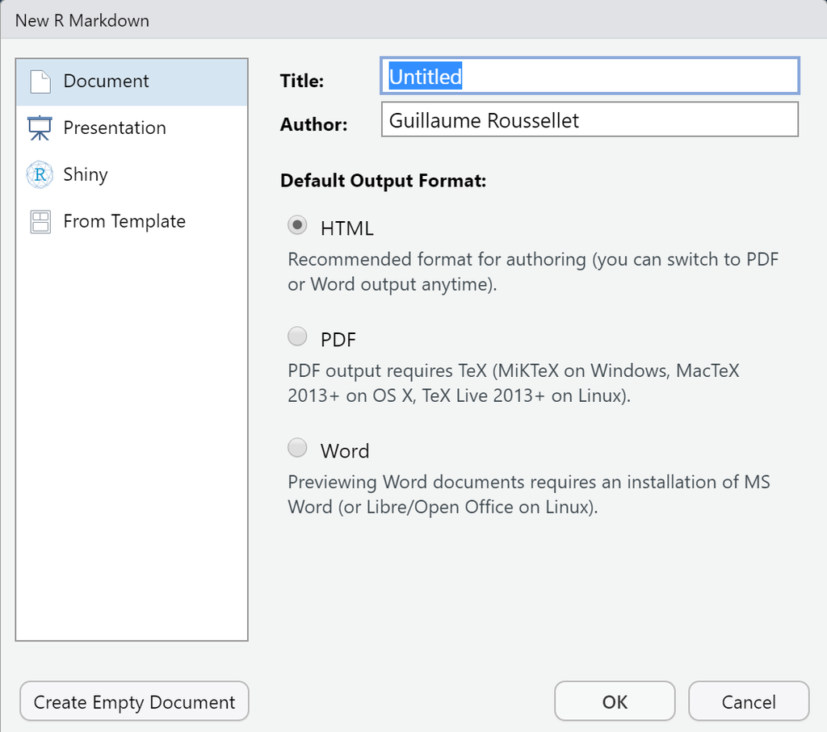

## Creating Markdown docs

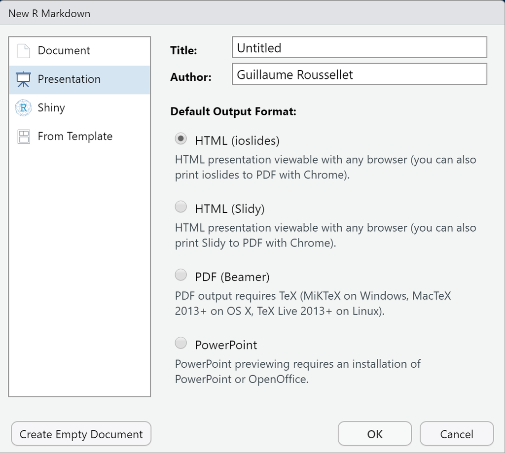